# Problem Set 5

Statistics 506, Fall 2020

Due: Friday December 4, by 7pm

## Instructions

- Submit the assignment by the due date via Canvas. Assignments may be submitted up to 72 hours late for a 5 point reduction.
- All files read, sourced, or referred to within scripts should be assumed to be in the same working directory (`./`).
- Your code should be clearly written and it should be possible to assess it by reading it. Use appropriate variable names and comments. Your style will be graded using the style rubric [15 points].
- Some of these exercises may require you to use commands or techniques that were not covered in class or in the course notes. You can use the web as needed to identify appropriate approaches. Part of the purpose of these exercises is for you to learn to be resourceful and self sufficient. Questions are welcome at all times, but please make an attempt to locate relevant information yourself first.
- Please use the provided [templates](https://github.com/jbhender/Stats506_F20/tree/master/problem_sets/templates/).
- This assignment should be done primarily in R, with the data.table package used for data management tasks. As always you may use the Linux shell for data preparation and download documentation.
- Your submission should include a write-up as a pdf or HTML document and all scripts needed to reproduce it. In your document, describe how the files submitted relate to one another and be sure to answer the questions.  
  For this assignment, scripts you should submit are: >R, Rmarkdown (`.Rmd` or `.R` with spin) for the write-up, the write up itself (`.pdf` or `.html`), and (optionally) a shell script (`.sh`) `ps4_make.sh` to build the assignment.

## Questions

### Question 1 [40 points]

In this question you will use R's data.table package to answer a question of your choosing about the RECS data used in previous problem sets.

1. [5 points] Pose a question about US residential homes that can be answered using one or both of the 2009 and 2015 RECS data sets. Then identify the variables that will be used answer the question. This question should not simply repeat posed in this (or any previous years) problem sets or examples.
2. [30 points] Carry out an analysis that helps you to answer the question you pose in part a using the `data.table` package for computations. As always, provide confidence intervals for all point estimates and present your results in nicely formatted graphs and/or tables.
3. [5 points] Answer the question you posed in part a using evidence from your analysis in part b. Your answer should be ~2-5 sentences.

#### Note

The question you pose in part a should be about homes in the US, not about the data itself. See the good and bad examples below for an illustration of the distinction.

A good question for part a:

> For which states (or reportable domains) has home internet access most chagned between 2009 and 2015? Is this difference larger in urban or rural areas?

A bad question for part a:

> For each state, how many homes in the 2009 and 2015 RECS samples didn't have internet access? Report by urban / rural.

The key difference is that the "good" version asks an inferential questions while the "bad" version focuses on the data itself, rather than the population it represents.

## Question 2 [45 points]

In this question, you will use cross-validation to compare the out-of-sample performance of three approaches to building models of the relationship between age and the presence of a permanent tooth. These approaches will build on what you did for question 2 in problem set 4. In the process, you will make use of asynchronous and/or parallel computing to speed up the model building and evaluation process. You can treat the data as iid for this question and do not need to make use of the survey weights or design.

1. [8 points] For subjects with a complete dentition exam in the NHANES data from problem set 4, create a data.table in long format where each row is the "Tooth Count" (e.g. `OHX[0-9]{2}TC`) status for a subject. Create a flag for whether a permanent tooth is present and merge in the subject's age from the demographics data. Here is a screen-shot for reference:

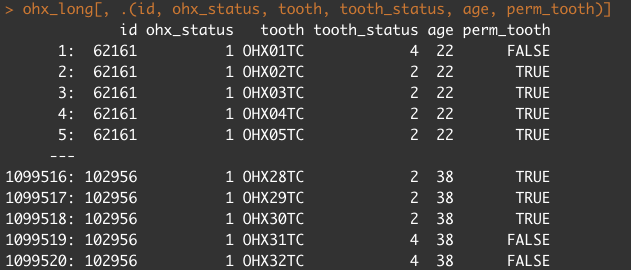

2. [2 points] Create a variable dividing the data into 4 folds based on the cohort from which the subjects came.
3. [30 points] For each modeling approach described below, use the function `mgcv::bam()` ("big additive model") to fit the model described to the training folds. Then, use the `predict()` method to estimate the probability that the a permanent tooth is present for each tooth in the held out fold. Repeat to get cross-validated predictions for each tooth. Use some form of parallel or asynchronous computing for this part.
4. [5 points] Compare the approaches below in terms of the cross-validated [cross entropy loss](https://en.wikipedia.org/wiki/Cross_entropy). Here, $\hat y$ is any of the cross-validated predictions from part "c" and $y = 1$ when a permanent tooth is present:

$$-\frac{1}{n} \sum_{i=1}^n
\left(y_i\log\hat y_i + (1 - y_i)\log(1 - \hat y_i) \right).$$

Approaches:

1. Use logistic regression to model the probability that a tooth is present as a smooth function of age (using a cubic smoothing spline) common to all teeth and a per-tooth indicator variable. Account for dependence among teeth within an individual subject using a random intercept. Using the variable names from the screen shot in part "a" the formula is:  
   `perm_tooth ~ tooth + s(age, bs = 'cs') + s(id, bs = 're')`.
2. Repeat the previous approach, but include an interaction between tooth and age as follows:  
   `perm_tooth ~ tooth + s(age, bs = 'cs', by = tooth) + s(id, bs = 're')`.
3. Repeat the previous step by modeling each tooth separately, so that the random intercepts are no longer needed:  
   `perm_tooth ~ s(age, bs = 'cs')`.

#### Notes:

- The data for question 2 are available in the `Stats506_F20` repository under `problem_sets/data/`. You will need the following two files:
- `nahanes_demo.csv`
- `nhanes_ohxden.csv`